# 2018 Pakistani General Election: electoral area (census block) data codebook

### Variables

#### constituency_ps_id_block_code

##### Distribution

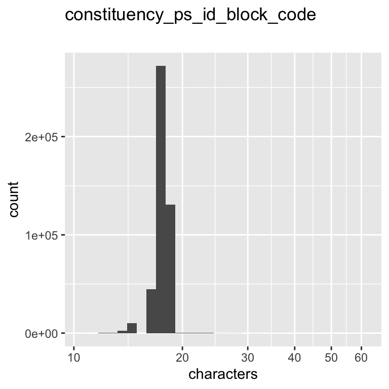

0 missing values.

##### Summary statistics

| name | data_type | missing | complete | n | empty | n_unique | min | max |
| --- | --- | --- | --- | --- | --- | --- | --- | --- |
| constituency_ps_id_block_code | character | 0 | 461320 | 461320 | 0 | 461320 | 11 | 62 |

#### constituency_ps_id

##### Distribution

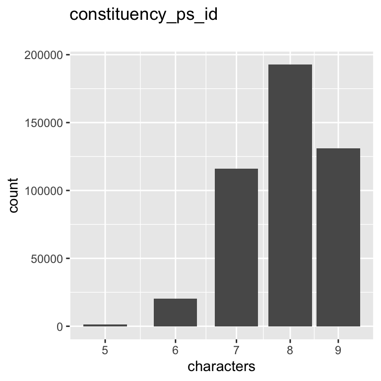

0 missing values.

##### Summary statistics

| name | data_type | missing | complete | n | empty | n_unique | min | max |
| --- | --- | --- | --- | --- | --- | --- | --- | --- |
| constituency_ps_id | character | 0 | 461320 | 461320 | 0 | 167616 | 5 | 9 |

#### province

##### Distribution

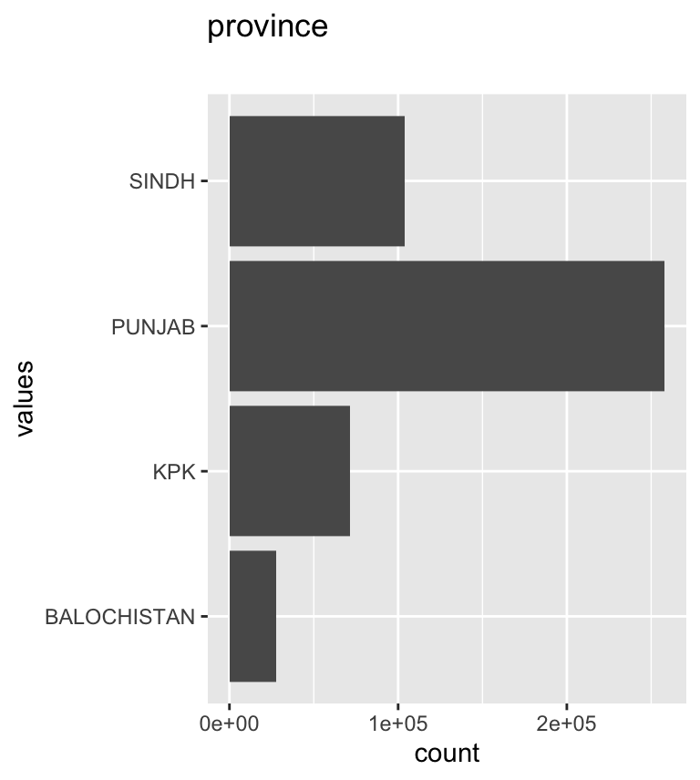

0 missing values.

##### Summary statistics

| name | data_type | missing | complete | n | empty | n_unique | min | max |
| --- | --- | --- | --- | --- | --- | --- | --- | --- |
| province | character | 0 | 461320 | 461320 | 0 | 4 | 3 | 11 |

#### assembly

##### Distribution

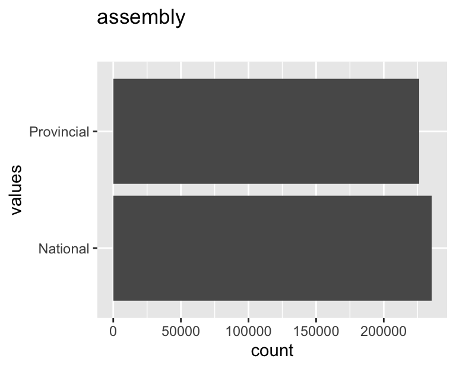

0 missing values.

##### Summary statistics

| name | data_type | missing | complete | n | empty | n_unique | min | max |
| --- | --- | --- | --- | --- | --- | --- | --- | --- |
| assembly | character | 0 | 461320 | 461320 | 0 | 2 | 8 | 10 |

#### constituency_id

##### Distribution

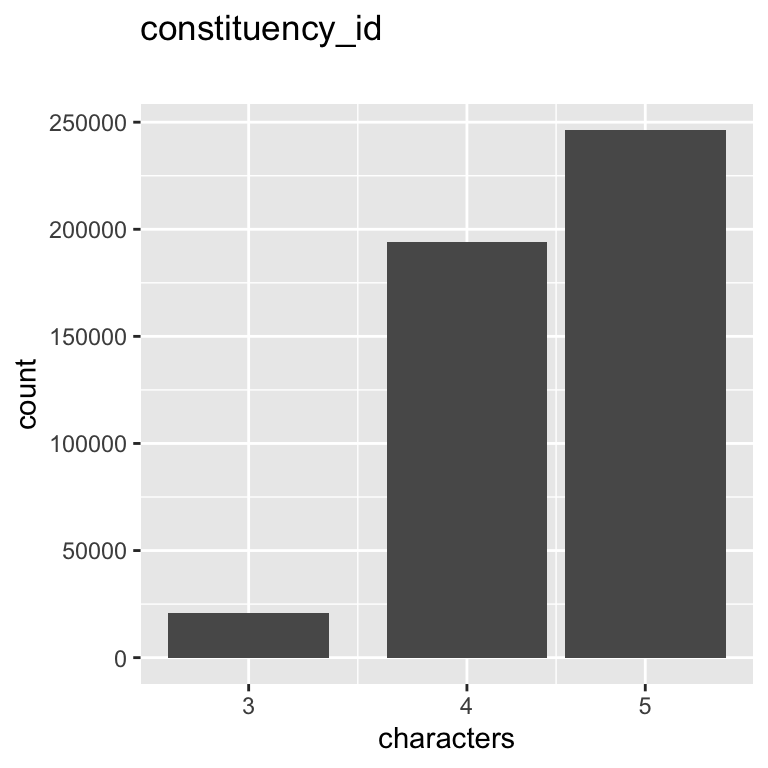

0 missing values.

##### Summary statistics

| name | data_type | missing | complete | n | empty | n_unique | min | max |
| --- | --- | --- | --- | --- | --- | --- | --- | --- |
| constituency_id | character | 0 | 461320 | 461320 | 0 | 849 | 3 | 5 |

#### constituency_area

##### Distribution

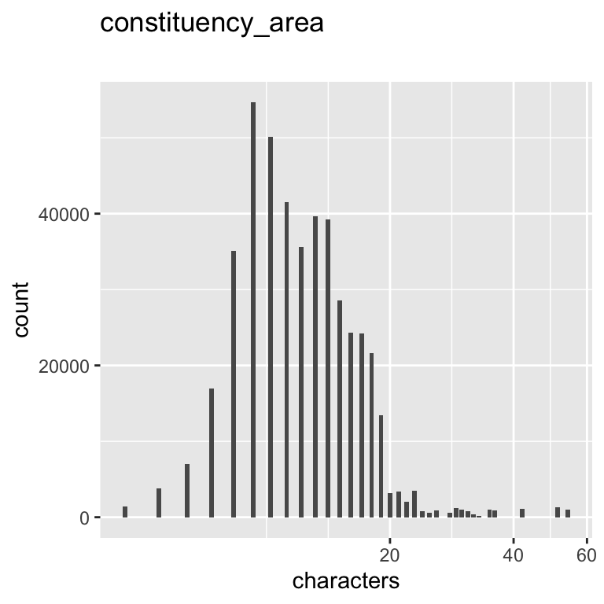

0 missing values.

##### Summary statistics

| name | data_type | missing | complete | n | empty | n_unique | min | max |
| --- | --- | --- | --- | --- | --- | --- | --- | --- |
| constituency_area | character | 0 | 461320 | 461320 | 0 | 682 | 4 | 54 |

#### ps_id

##### Distribution

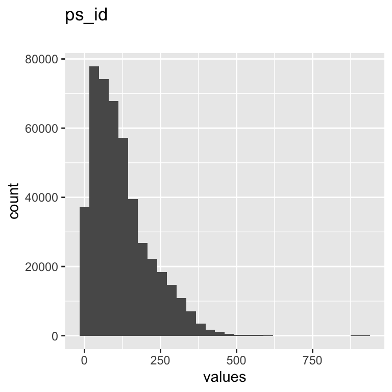

0 missing values.

##### Summary statistics

| name | data_type | missing | complete | n | mean | sd | p0 | p25 | p50 | p75 | p100 | hist |
| --- | --- | --- | --- | --- | --- | --- | --- | --- | --- | --- | --- | --- |
| ps_id | integer | 0 | 461320 | 461320 | 120.13 | 94.13 | 1 | 48 | 98 | 168 | 924 | ▇▃▂▁▁▁▁▁ |

#### ps_name_from_form28

##### Distribution

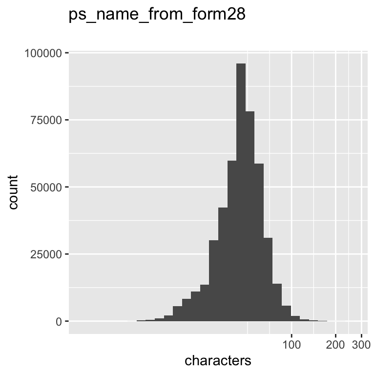

0 missing values.

##### Summary statistics

| name | data_type | missing | complete | n | empty | n_unique | min | max |
| --- | --- | --- | --- | --- | --- | --- | --- | --- |
| ps_name_from_form28 | character | 0 | 461320 | 461320 | 0 | 83096 | 3 | 242 |

#### block_code

##### Distribution

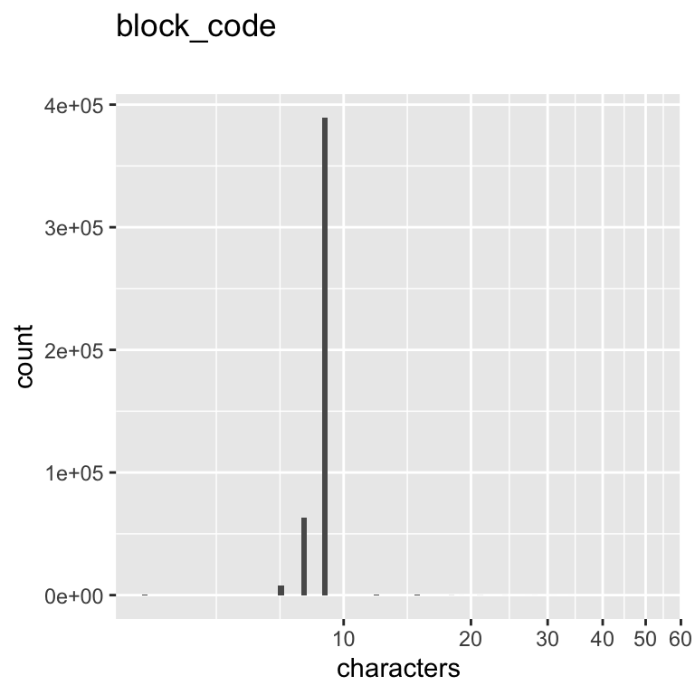

30 missing values.

##### Summary statistics

| name | data_type | missing | complete | n | empty | n_unique | min | max |
| --- | --- | --- | --- | --- | --- | --- | --- | --- |
| block_code | character | 30 | 461290 | 461320 | 0 | 163074 | 3 | 52 |

#### block_code_type

##### Distribution

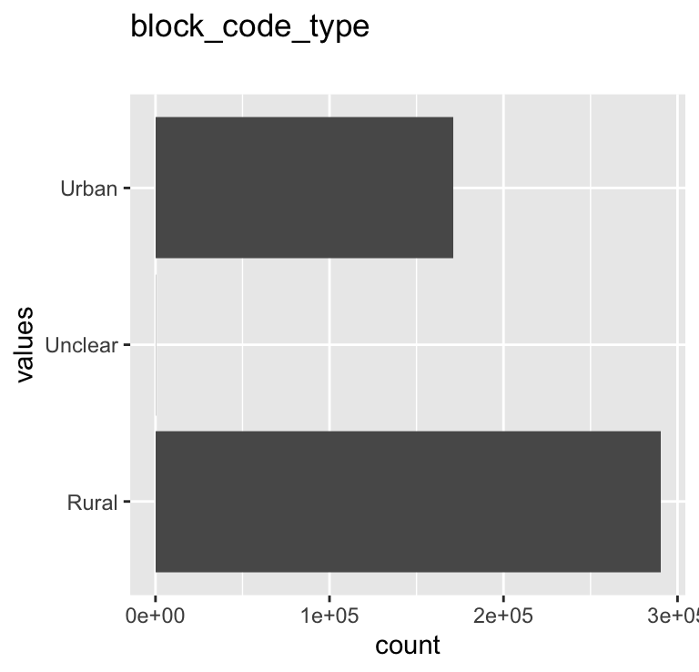

0 missing values.

##### Summary statistics

| name | data_type | missing | complete | n | empty | n_unique | min | max |
| --- | --- | --- | --- | --- | --- | --- | --- | --- |
| block_code_type | character | 0 | 461320 | 461320 | 0 | 3 | 5 | 7 |

#### name_ea_rural

##### Distribution

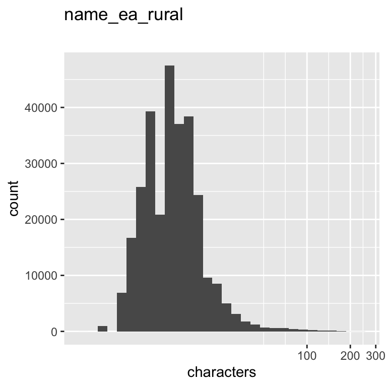

170869 missing values.

##### Summary statistics

| name | data_type | missing | complete | n | empty | n_unique | min | max |
| --- | --- | --- | --- | --- | --- | --- | --- | --- |
| name_ea_rural | character | 170869 | 290451 | 461320 | 0 | 52597 | 2 | 244 |

#### name_ea_urban

##### Distribution

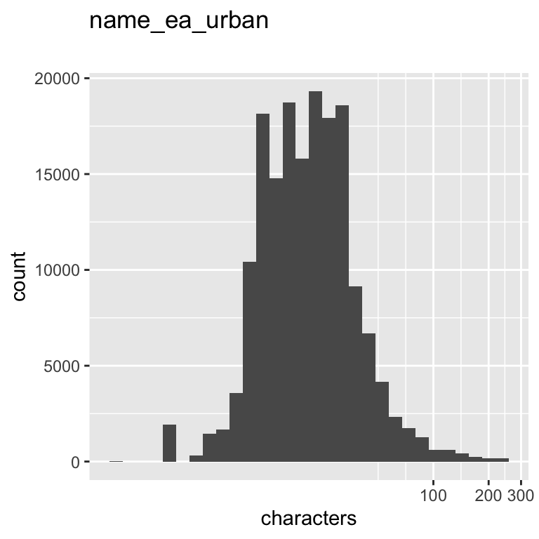

291065 missing values.

##### Summary statistics

| name | data_type | missing | complete | n | empty | n_unique | min | max |
| --- | --- | --- | --- | --- | --- | --- | --- | --- |
| name_ea_urban | character | 291065 | 170255 | 461320 | 0 | 25992 | 1 | 244 |

#### voter_serials_assigned_to_station

##### Distribution

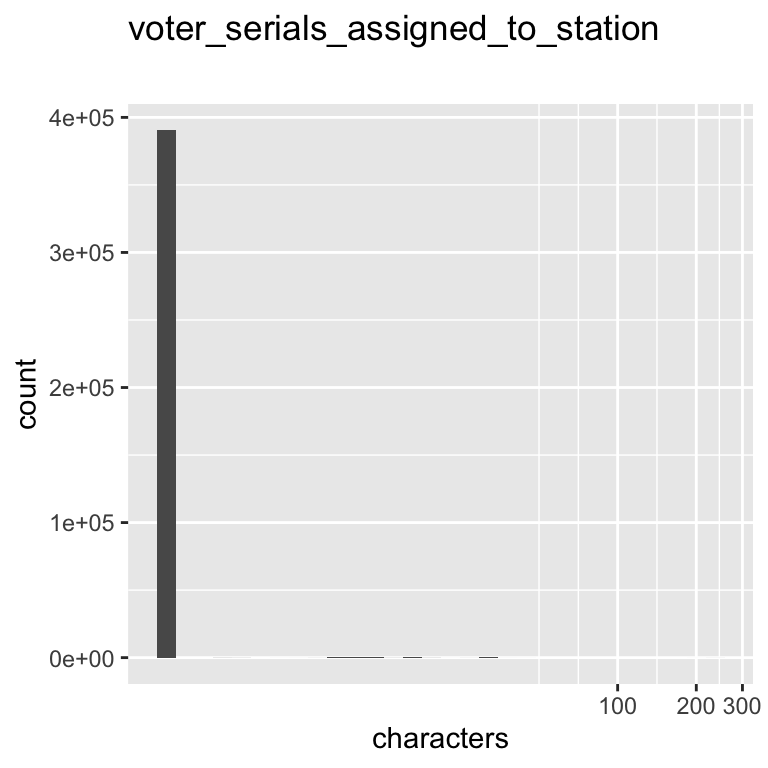

69248 missing values.

##### Summary statistics

| name | data_type | missing | complete | n | empty | n_unique | min | max |
| --- | --- | --- | --- | --- | --- | --- | --- | --- |
| voter_serials_assigned_to_station | character | 69248 | 392072 | 461320 | 0 | 632 | 1 | 244 |

#### male_voters

##### Distribution

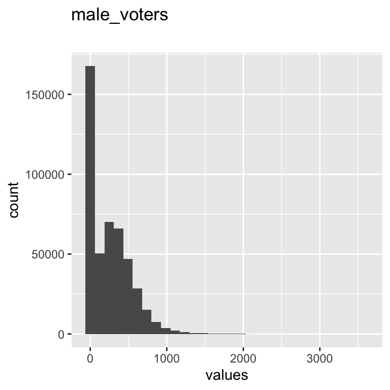

122 missing values.

##### Summary statistics

| name | data_type | missing | complete | n | mean | sd | p0 | p25 | p50 | p75 | p100 | hist |
| --- | --- | --- | --- | --- | --- | --- | --- | --- | --- | --- | --- | --- |
| male_voters | integer | 122 | 461198 | 461320 | 252.54 | 265.27 | 0 | 0 | 208 | 413 | 3573 | ▇▂▁▁▁▁▁▁ |

#### female_voters

##### Distribution

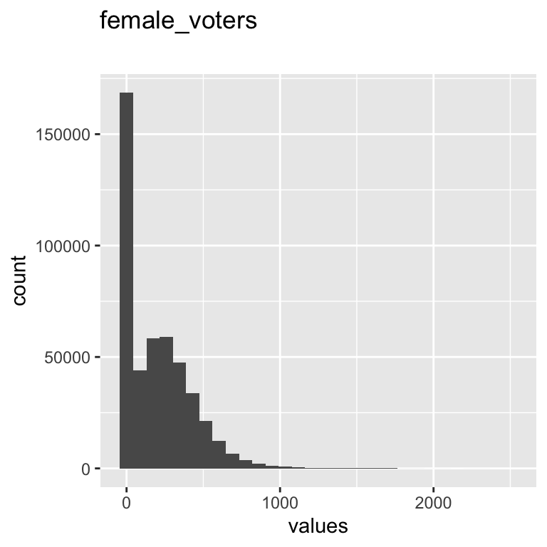

162 missing values.

##### Summary statistics

| name | data_type | missing | complete | n | mean | sd | p0 | p25 | p50 | p75 | p100 | hist |
| --- | --- | --- | --- | --- | --- | --- | --- | --- | --- | --- | --- | --- |
| female_voters | integer | 162 | 461158 | 461320 | 199.47 | 214.25 | 0 | 0 | 158 | 327 | 2499 | ▇▂▁▁▁▁▁▁ |

#### total_voters

##### Distribution

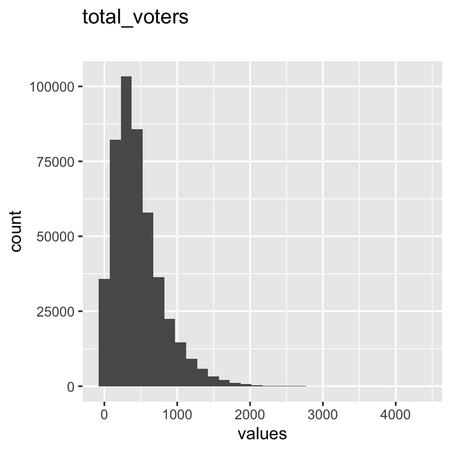

153 missing values.

##### Summary statistics

| name | data_type | missing | complete | n | mean | sd | p0 | p25 | p50 | p75 | p100 | hist |
| --- | --- | --- | --- | --- | --- | --- | --- | --- | --- | --- | --- | --- |
| total_voters | integer | 153 | 461167 | 461320 | 458.75 | 338.62 | 0 | 221 | 389 | 616 | 4341 | ▇▃▁▁▁▁▁▁ |

#### male_booths

##### Distribution

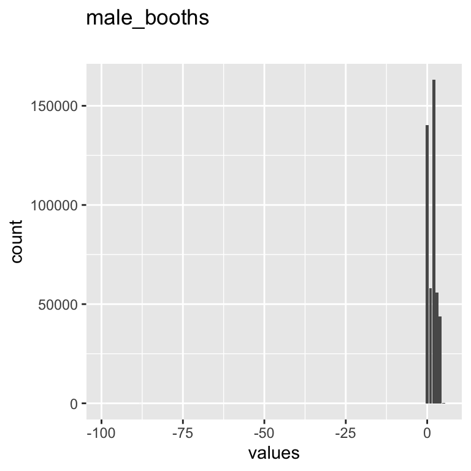

102 missing values.

##### Summary statistics

| name | data_type | missing | complete | n | mean | sd | p0 | p25 | p50 | p75 | p100 | hist |
| --- | --- | --- | --- | --- | --- | --- | --- | --- | --- | --- | --- | --- |
| male_booths | integer | 102 | 461218 | 461320 | 1.57 | 1.53 | -99 | 0 | 2 | 2 | 5 | ▁▁▁▁▁▁▁▇ |

#### female_booths

##### Distribution

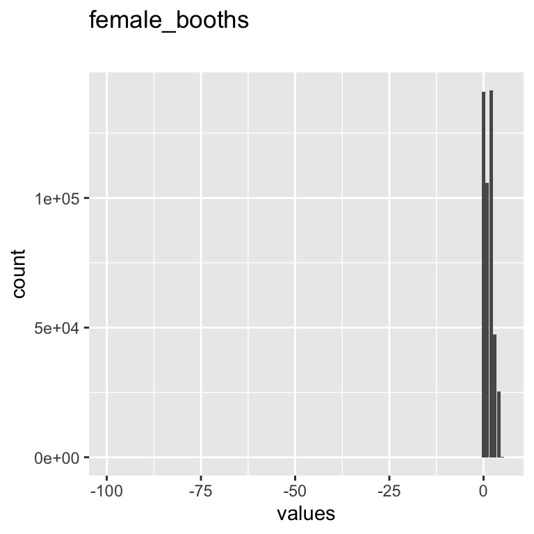

102 missing values.

##### Summary statistics

| name | data_type | missing | complete | n | mean | sd | p0 | p25 | p50 | p75 | p100 | hist |
| --- | --- | --- | --- | --- | --- | --- | --- | --- | --- | --- | --- | --- |
| female_booths | integer | 102 | 461218 | 461320 | 1.37 | 1.43 | -99 | 0 | 1 | 2 | 5 | ▁▁▁▁▁▁▁▇ |

#### total_booths

##### Distribution

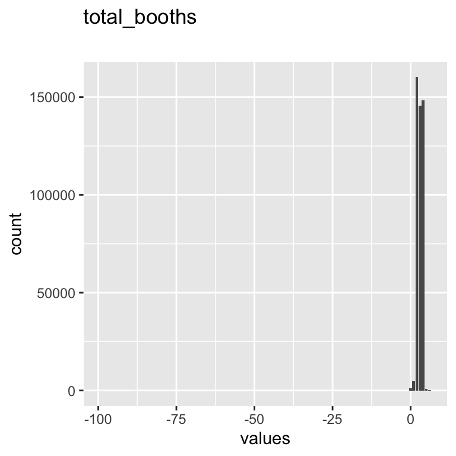

102 missing values.

##### Summary statistics

| name | data_type | missing | complete | n | mean | sd | p0 | p25 | p50 | p75 | p100 | hist |
| --- | --- | --- | --- | --- | --- | --- | --- | --- | --- | --- | --- | --- |
| total_booths | integer | 102 | 461218 | 461320 | 2.94 | 1.2 | -99 | 2 | 3 | 4 | 6 | ▁▁▁▁▁▁▁▇ |